# IE 582 HW - English Premier League

```python
import numpy as np
import pandas as pd
import matplotlib.pyplot as plt
from scipy.stats import poisson
```

```python
df1 = pd.read_csv('Season 2020-2021.csv')
df1 = df1.drop(labels=None, axis=0, index=None, columns='Time', level=None, inplace=False, errors='raise')
df2 = pd.read_csv('Season 2019-2020.csv')
df2 = df2.drop(labels=None, axis=0, index=None, columns='Time', level=None, inplace=False, errors='raise')
df3 = pd.read_csv('Season 2018-2019.csv')
df3 = df3.rename(columns={"BbMxH": "MaxH", "BbAvH" : "AvgH", "BbMxD" : "MaxD", "BbAvD" : "AvgD", "BbMxA" : "MaxA", "BbAvA" : "AvgA", "BbMx>2.5" : "Max>2.5", "BbMx<2.5" : "Max<2.5", "BbAv>2.5" : "Avg>2.5", "BbAv<2.5" : "Avg<2.5"})
frames = [df1, df2, df3]
df = pd.concat(frames, keys=['Season 2020-2021', 'Season 2019-2020', 'Season 2018-2019'])
df = df.iloc[:, 0:55]
df
```

|  |  | Div | Date | HomeTeam | AwayTeam | FTHG | FTAG | FTR | HTHG | HTAG | HTR | ... | AvgD | AvgA | B365>2.5 | B365<2.5 | P>2.5 | P<2.5 | Max>2.5 | Max<2.5 | Avg>2.5 | Avg<2.5 |
| --- | --- | --- | --- | --- | --- | --- | --- | --- | --- | --- | --- | --- | --- | --- | --- | --- | --- | --- | --- | --- | --- | --- |
| Season 2020-2021 | 0 | E0 | 12/09/2020 | Fulham | Arsenal | 0 | 3 | A | 0 | 1 | A | ... | 4.34 | 1.55 | 1.72 | 2.10 | 1.80 | 2.13 | 1.84 | 2.18 | 1.76 | 2.10 |
|  | 1 | E0 | 12/09/2020 | Crystal Palace | Southampton | 1 | 0 | H | 1 | 0 | H | ... | 3.22 | 2.39 | 2.20 | 1.66 | 2.34 | 1.68 | 2.36 | 1.73 | 2.24 | 1.67 |
|  | 2 | E0 | 12/09/2020 | Liverpool | Leeds | 4 | 3 | H | 3 | 2 | H | ... | 5.96 | 9.68 | 1.53 | 2.50 | 1.56 | 2.60 | 1.56 | 2.68 | 1.52 | 2.53 |
|  | 3 | E0 | 12/09/2020 | West Ham | Newcastle | 0 | 2 | A | 0 | 0 | D | ... | 3.48 | 3.42 | 1.90 | 1.90 | 2.00 | 1.91 | 2.05 | 1.95 | 1.97 | 1.86 |
|  | 4 | E0 | 13/09/2020 | West Brom | Leicester | 0 | 3 | A | 0 | 0 | D | ... | 3.57 | 1.97 | 1.90 | 1.90 | 2.00 | 1.91 | 2.02 | 2.03 | 1.92 | 1.90 |
| ... | ... | ... | ... | ... | ... | ... | ... | ... | ... | ... | ... | ... | ... | ... | ... | ... | ... | ... | ... | ... | ... | ... |
| Season 2018-2019 | 375 | E0 | 12/05/2019 | Liverpool | Wolves | 2 | 0 | H | 1 | 0 | H | ... | 5.62 | 10.17 | NaN | NaN | NaN | NaN | 1.65 | 2.43 | 1.61 | 2.31 |
|  | 376 | E0 | 12/05/2019 | Man United | Cardiff | 0 | 2 | A | 0 | 1 | A | ... | 6.18 | 10.10 | NaN | NaN | NaN | NaN | 1.45 | 3.25 | 1.39 | 2.95 |
|  | 377 | E0 | 12/05/2019 | Southampton | Huddersfield | 1 | 1 | D | 1 | 0 | H | ... | 4.81 | 7.64 | NaN | NaN | NaN | NaN | 1.67 | 2.40 | 1.62 | 2.29 |
|  | 378 | E0 | 12/05/2019 | Tottenham | Everton | 2 | 2 | D | 1 | 0 | H | ... | 3.51 | 3.58 | NaN | NaN | NaN | NaN | 1.81 | 2.18 | 1.76 | 2.07 |
|  | 379 | E0 | 12/05/2019 | Watford | West Ham | 1 | 4 | A | 0 | 2 | A | ... | 3.73 | 3.13 | NaN | NaN | NaN | NaN | 1.60 | 2.56 | 1.55 | 2.44 |

838 rows × 55 columns

I checked the column names all together to see if there are differences and then I updated and renamed them above

```python
col_mapping1 = [f"{c[0]}:{c[1]}" for c in enumerate(df1.columns)]
col_mapping2 = [f"{c[0]}:{c[1]}" for c in enumerate(df2.columns)]
col_mapping3 = [f"{c[0]}:{c[1]}" for c in enumerate(df3.columns)]
columns_names = pd.DataFrame([col_mapping1, col_mapping2, col_mapping3])
columns_names
```

|  | 0 | 1 | 2 | 3 | 4 | 5 | 6 | 7 | 8 | 9 | ... | 95 | 96 | 97 | 98 | 99 | 100 | 101 | 102 | 103 | 104 |
| --- | --- | --- | --- | --- | --- | --- | --- | --- | --- | --- | --- | --- | --- | --- | --- | --- | --- | --- | --- | --- | --- |
| 0 | 0:Div | 1:Date | 2:HomeTeam | 3:AwayTeam | 4:FTHG | 5:FTAG | 6:FTR | 7:HTHG | 8:HTAG | 9:HTR | ... | 95:AvgC<2.5 | 96:AHCh | 97:B365CAHH | 98:B365CAHA | 99:PCAHH | 100:PCAHA | 101:MaxCAHH | 102:MaxCAHA | 103:AvgCAHH | 104:AvgCAHA |
| 1 | 0:Div | 1:Date | 2:HomeTeam | 3:AwayTeam | 4:FTHG | 5:FTAG | 6:FTR | 7:HTHG | 8:HTAG | 9:HTR | ... | 95:AvgC<2.5 | 96:AHCh | 97:B365CAHH | 98:B365CAHA | 99:PCAHH | 100:PCAHA | 101:MaxCAHH | 102:MaxCAHA | 103:AvgCAHH | 104:AvgCAHA |
| 2 | 0:Div | 1:Date | 2:HomeTeam | 3:AwayTeam | 4:FTHG | 5:FTAG | 6:FTR | 7:HTHG | 8:HTAG | 9:HTR | ... | None | None | None | None | None | None | None | None | None | None |

3 rows × 105 columns

# Task 1.1

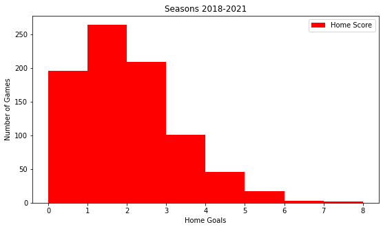

```python
bins=np.arange(min(df.FTHG), max(df.FTHG) + 1, 1)
plt.figure(figsize=(9,5))
plt.hist(df.FTHG, bins=np.arange(min(df.FTHG), max(df.FTHG) + 1, 1), color='r', label='Home Score')
plt.xticks(bins)
plt.ylabel('Number of Games')
plt.xlabel('Home Goals')
plt.title('Seasons 2018-2021')
plt.legend()
plt.show()
```

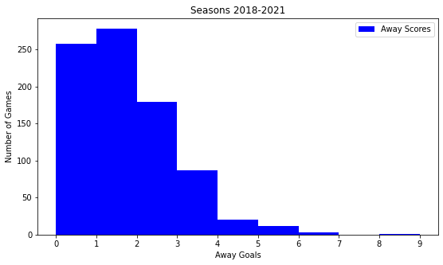

```python
bins=np.arange(min(df.FTAG), max(df.FTAG) + 1, 1)
plt.figure(figsize=(9,5))
plt.hist(df.FTAG, bins=np.arange(min(df.FTAG), max(df.FTAG) + 1, 1), color='b', label='Away Scores')
plt.xticks(bins)
plt.ylabel('Number of Games')
plt.xlabel('Away Goals')
plt.title('Seasons 2018-2021')
plt.legend()
plt.show()
```

```python
df['FTHGnFTAG'] = df['FTHG']-df['FTAG']
```

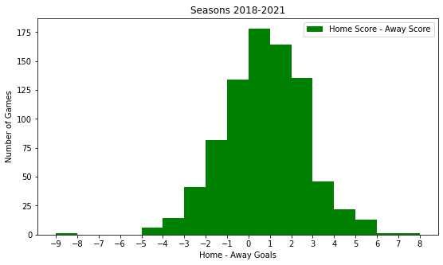

```python
bins=np.arange(min(df.FTHGnFTAG), max(df.FTHGnFTAG) + 1, 1)
plt.figure(figsize=(9,5))
plt.hist(df.FTHGnFTAG,bins=np.arange(min(df.FTHGnFTAG), max(df.FTHGnFTAG) + 1, 1), color='g', label=['Home Score - Away Score'])
plt.xticks(bins)
plt.ylabel('Number of Games')
plt.xlabel('Home - Away Goals')
plt.title('Seasons 2018-2021')
plt.legend()
plt.show()
```

```python
#I save the data to check it
##df.to_excel('modified4.xlsx')
```

# Task 1.2

Home and Away Goals' distributions looks similar to Poisson Distribution with different constants.

```python
df.describe()
```

|  | FTHG | FTAG | HTHG | HTAG | HS | AS | HST | AST | HF | AF | ... | AvgA | B365>2.5 | B365<2.5 | P>2.5 | P<2.5 | Max>2.5 | Max<2.5 | Avg>2.5 | Avg<2.5 | FTHGnFTAG |
| --- | --- | --- | --- | --- | --- | --- | --- | --- | --- | --- | --- | --- | --- | --- | --- | --- | --- | --- | --- | --- | --- |
| count | 838.000000 | 838.000000 | 838.000000 | 838.000000 | 838.000000 | 838.000000 | 838.000000 | 838.000000 | 838.000000 | 838.000000 | ... | 838.000000 | 458.000000 | 458.000000 | 458.000000 | 458.000000 | 838.000000 | 838.000000 | 838.000000 | 838.000000 | 838.000000 |
| mean | 1.535800 | 1.269690 | 0.695704 | 0.571599 | 13.545346 | 11.285203 | 4.632458 | 4.000000 | 10.483294 | 10.663484 | ... | 4.983043 | 1.801157 | 2.141528 | 1.847205 | 2.219585 | 1.886683 | 2.246921 | 1.817792 | 2.139964 | 0.266110 |
| std | 1.299952 | 1.214729 | 0.879478 | 0.769182 | 5.592683 | 5.004280 | 2.590949 | 2.418566 | 3.473275 | 3.639210 | ... | 4.928992 | 0.284861 | 0.478972 | 0.305721 | 0.509628 | 0.321525 | 0.518953 | 0.296892 | 0.463692 | 1.931212 |
| min | 0.000000 | 0.000000 | 0.000000 | 0.000000 | 0.000000 | 1.000000 | 0.000000 | 0.000000 | 0.000000 | 1.000000 | ... | 1.130000 | 1.220000 | 1.440000 | 1.200000 | 1.470000 | 1.220000 | 1.500000 | 1.210000 | 1.450000 | -9.000000 |
| 25% | 1.000000 | 0.000000 | 0.000000 | 0.000000 | 10.000000 | 8.000000 | 3.000000 | 2.000000 | 8.000000 | 8.000000 | ... | 2.260000 | 1.570000 | 1.800000 | 1.620000 | 1.860000 | 1.650000 | 1.880000 | 1.600000 | 1.810000 | -1.000000 |
| 50% | 1.000000 | 1.000000 | 0.000000 | 0.000000 | 13.000000 | 11.000000 | 4.000000 | 4.000000 | 10.000000 | 10.000000 | ... | 3.305000 | 1.800000 | 2.015000 | 1.810000 | 2.120000 | 1.850000 | 2.130000 | 1.790000 | 2.040000 | 0.000000 |
| 75% | 2.000000 | 2.000000 | 1.000000 | 1.000000 | 17.000000 | 14.000000 | 6.000000 | 5.000000 | 13.000000 | 13.000000 | ... | 5.597500 | 2.000000 | 2.370000 | 2.050000 | 2.440000 | 2.100000 | 2.470000 | 2.010000 | 2.347500 | 2.000000 |
| max | 8.000000 | 9.000000 | 5.000000 | 5.000000 | 36.000000 | 28.000000 | 14.000000 | 15.000000 | 23.000000 | 24.000000 | ... | 40.610000 | 2.750000 | 4.330000 | 2.860000 | 5.060000 | 2.900000 | 5.060000 | 2.740000 | 4.450000 | 8.000000 |

8 rows × 49 columns

```python
df["FTHG"].mean()
```

```
1.535799522673031
```

```python
df["FTAG"].mean()
```

```
1.269689737470167
```

```python
df["FTHGnFTAG"].count()
```

```
838
```

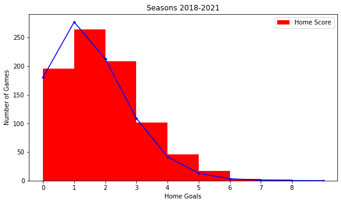

```python
bins=np.arange(min(df.FTHG), max(df.FTHG) + 1, 1)
plt.figure(figsize=(9,5))
plt.hist(df.FTHG,bins=np.arange(min(df.FTHG), max(df.FTHG) + 1, 1), color='r', label=['Home Score'])

p1= poisson(df["FTHG"].mean())
n = 9
x = np.linspace(0,n,n+1)
pmf1 = (np.array([p1.pmf(i) for i in x]))*df["FTHG"].count()
plt.plot(x, pmf1, 'b', marker = '.')

plt.xticks(bins)
plt.ylabel('Number of Games')
plt.xlabel('Home Goals')
plt.title('Seasons 2018-2021')
plt.legend()
plt.show()
```

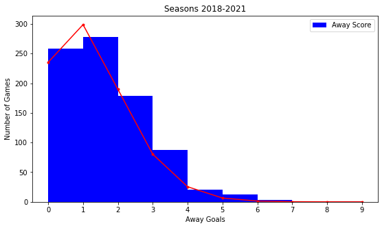

```python
bins=np.arange(min(df.FTAG), max(df.FTAG) + 1, 1)
plt.figure(figsize=(9,5))
plt.hist(df.FTAG,bins=np.arange(min(df.FTAG), max(df.FTAG) + 1, 1), color='b', label=['Away Score'])

p1= poisson(df["FTAG"].mean())
n = 9
x = np.linspace(0,n,n+1)
pmf1 = (np.array([p1.pmf(i) for i in x]))*df["FTAG"].count()
plt.plot(x, pmf1, 'r', marker = '.')

plt.xticks(bins)
plt.ylabel('Number of Games')
plt.xlabel('Away Goals')
plt.title('Seasons 2018-2021')
plt.legend()
plt.show()
```

They are not exactly same and there are slight differences. However, expected number of games (theoritical distribution) corresponding to each quantile seems consistent with histogram (actual outcome) for both Home and Away Goals.

# Task 2

## Selected Bookmakers are Bet365, BetAndWin, Some Bookmaker #1 and Pinnacle

```python
#Number and Name of Columns
##df_columns = [f"{c[0]}:{c[1]}" for c in enumerate(df.columns)]
##df_columns
```

```python
#df["HR"].describe()
```

```python
#df["AR"].describe()
```

```
Bet365
```

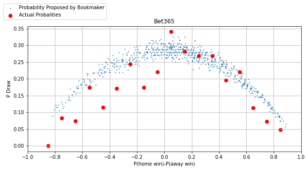

```
BetAndWin
```

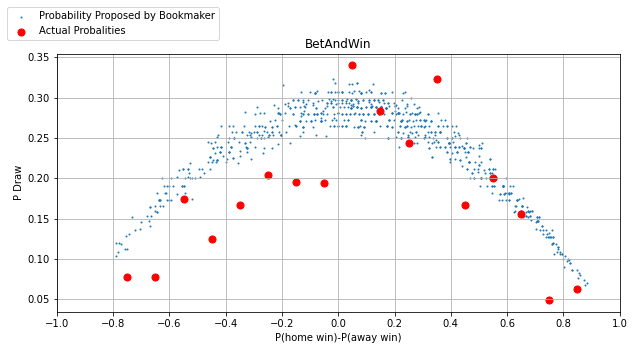

```
Some Bookmaker #1
```

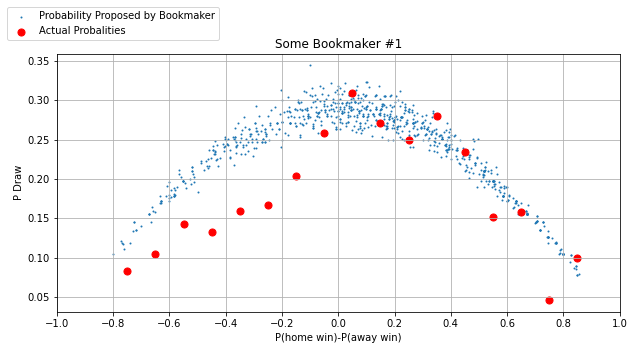

```
Pinnacle
```

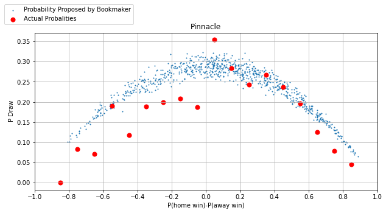

```python
x=[23,26,29,32]

for i in x:
    if i == 23:
        print('Bet365')
    elif i == 26:
        print('BetAndWin')
    elif i == 29:
        print('Some Bookmaker #1')
    elif i == 32:
        print('Pinnacle')

    new_df = df[[df.columns[6], df.columns[21],df.columns[22], df.columns[i], df.columns[i+1], df.columns[i+2]]].copy()
    #new_df["FTR"] = df[[df.columns[6]]]
    new_df.iloc[:,3:6] = df[[df.columns[i], df.columns[i+1], df.columns[i+2]]].copy().rdiv(1)
    new_df["Total"] = new_df.iloc[:, 3:6].sum(axis=1)

    new_df.iloc[:,3:7] = new_df.iloc[:,3:7].div(new_df.Total, axis=0)

    new_df["PH-PA"] = new_df[new_df.columns[3]] - new_df[new_df.columns[5]]
    new_df.loc[new_df['FTR']=='D','Draw_Count'] = 1

    interval = 0.1
    bins_df = new_df.groupby(pd.cut(new_df["PH-PA"], np.arange(-1, 1.0 + interval , interval))).count()
    bins_df["P_Draw"] = bins_df["Draw_Count"]/bins_df["PH-PA"]
    bins_df["Bins"] = np.arange(-1 + interval/2 , 1.0, interval)
    bins_df

    plt.figure(figsize=(9,5))
    plt.scatter(new_df["PH-PA"], new_df[new_df.columns[4]], s = 1)
    plt.scatter(bins_df["Bins"] , bins_df["P_Draw"], s = 50, c='r')
    plt.xticks([-1.0, -0.8, -0.6, -0.4, -0.2, 0, 0.2, 0.4, 0.6, 0.8, 1.0])
    plt.ylabel('P Draw')
    plt.xlabel('P(home win)-P(away win)')

    plt.legend(['Probability Proposed by Bookmaker','Actual Probalities'], bbox_to_anchor=(0.1, 1.2), loc='upper center')
    plt.tight_layout()
    plt.grid(b=None, which='major', axis='both')
    if i == 23:
        plt.title('Bet365')
        plt.savefig('Bet365 Scatter Plot-Red Cards Included.png',dpi=300)
    elif i == 26:
        plt.title('BetAndWin')
        plt.savefig('BetAndWin Scatter Plot-Red Cards Included.png',dpi=300)
    elif i == 29:
        plt.title('Some Bookmaker #1')
        plt.savefig('Some Bookmaker #1 Scatter Plot-Red Cards Included.png',dpi=300)
    elif i == 32:
        plt.title('Pinnacle')
        plt.savefig('Pinnacle Scatter Plot-Red Cards Included.png',dpi=300)

    plt.show()
```

Bet365 and pinnacle seem to have better odds(probability) which are closer to actual probabilities. In the long run, it seems possible to make money by betting on draw in the bin~(0,0.1]. According to BetAndWin and Somebookmakers odds, it seems like there is bias.